# Class 3 Assignment - SQL with CARTO

## Concepts & Themes:

This week’s assignment will encompass the following concepts, some of which will be previewed during the **Class 3**:

- CARTO Analyses
- CARTO SQL general syntax
- CARTO SQL default statement structure
- CARTO SQL conditional statements

## Class 3 Links:

- [Agenda](https://gis-nspe-tns.github.io/GIS_NINT5423_spring_2023/agendas/c3_agenda_spring_23_NINT5423.html)
- [Lecture 3](https://gis-nspe-tns.github.io/GIS_NINT5423_spring_2023/lectures/lecture.3/index.html)
- [Assignment 3 (This Document)](https://gis-nspe-tns.github.io/GIS_NINT5423_spring_2023/assignments/c3_assignment_spring_23_NINT5423.html)
- [Lecture Demonstration](https://gis-nspe-tns.github.io/GIS_NINT5423_spring_2023/demos/c3.lecture.demo.html)
- [Class 3 Demonstration Code](https://gis-nspe-tns.github.io/GIS_NINT5423_spring_2023/demo_code/c3_sql_code.sql)
- [Class 3 CARTO Analysis Video Guide](https://vimeo.com/748798893)
- [Class 3 CARTO SQL Video Guide](https://vimeo.com/748803470)
- [Class 3 Lecture Demo Data](https://www.dropbox.com/s/ym6c59hbxosk9qo/c3_inclass-data.zip?dl=1)

### Class 3 CARTO Analysis Video Guide:

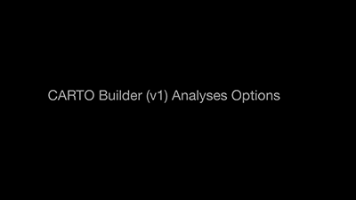

### Class 3 CARTO SQL Video Guide:

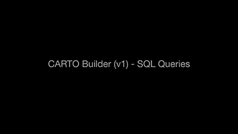

### CartoCSS Reference Links + PDFs:

- [SQL Cheatsheet](https://gis-nint4523.s3.us-east-2.amazonaws.com/pdf-materials/sql-cheatsheet.pdf)
- [PostGIS SQL Cheatsheet](https://gis-nint4523.s3.us-east-2.amazonaws.com/pdf-materials/sql-postgis-cheatsheet.pdf)
- [CARTO SQL Complete Documentation Guide Online - See SQL section](https://carto.com/help/working-with-data/)
- [SQL Query Statements used for demonstration in CARTO SQL Video](https://gis-nspe-tns.github.io/GIS_NINT5423_spring_2023/demo_code/c3_sql_code.sql)

## Data Acquisition (Step #1):

This week’s assignment will consist of two parts. First for Part #1, a series of SQL queries that you run on datasets that are either currently in your CARTO account; or a dataset(s) that you newly upload. As a default, you could utilize the [Class 3 Lecture Demo Data](https://www.dropbox.com/s/ym6c59hbxosk9qo/c3_inclass-data.zip?dl=1).

The dataset for Part #2 is Airbnb archived data for [unique global cities available HERE](http://insideairbnb.com/get-the-data.html). To access, find the city that you are interested in working with in Part #2, and download its `listings.csv` instance. That dataset can then be loaded to CARTO as a `.csv`. The `latitude` and `longitude` columns in the dataset will be read by CARTO as geographic coordinates and stored as `the_geom` for mapping purposes. Conduct your SQL queries on the dataset now loaded to CARTO.

[figure not shown]

Airbnb Data Site

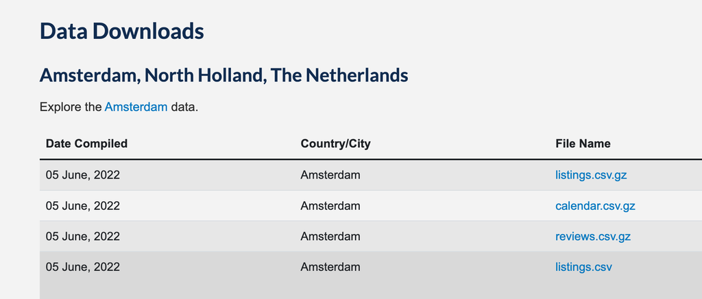

City Amsterdam; note the `listings.csv` amongst other download options

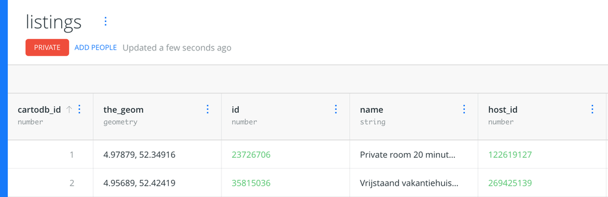

Preview of City Amsterdam `listings.csv` loaded to CARTO

## Part I SQL Queries (Step #2):

In this first assignment component, conduct 5 unique SQL query statements, one of which will be a *non-spatial* query (for instance a `COUNT` query).

Create a text document listing out your 5 SQL queries, making sure to separate each one for each access/viewing. Provide a screengrab of each successful result within the SQL and Map interface:

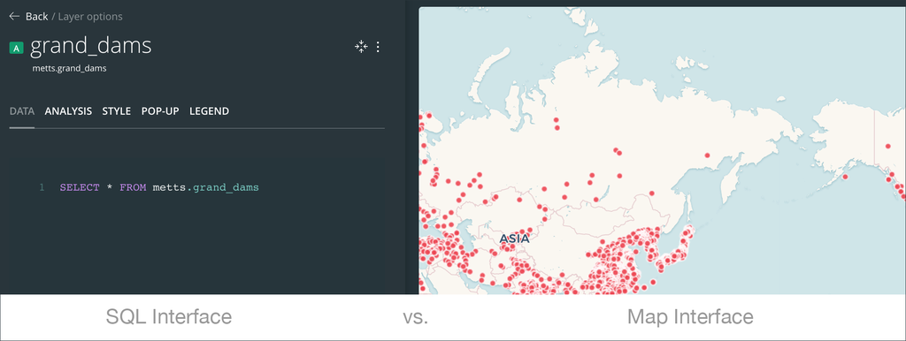

SQL + Map Interface

## Part II SQL Queries (Step #3):

Using SQL and data from Inside Airbnb for the *city of your choice* answer the following 4 questions:

1. How many Airbnb listings are there in the city you chose?
2. How many listings are there in each neighborhood?
3. What is the average price for an listing?
4. Make a map where you filter the listings somehow (for example, showing listings with “beautiful” in their name).
- For query #1, this can be accomplished by the non-spatial `COUNT` operator.
- For query #2, utilize *Count in groups* from the [SQL Cheatsheet](https://gis-nint4523.s3.us-east-2.amazonaws.com/pdf-materials/sql-cheatsheet.pdf).
- For query #3 above, average is a similar EDA statistic to count; utilize [w3schools overview](https://www.w3schools.com/sql/sql_count_avg_sum.asp) to understand the syntax of both.
- For query #4 above, finding a subset string/text within a larger string/text can be accomplished with the `ILIKE` operator as described in this [overview](https://mode.com/sql-tutorial/sql-like/). A description of the `ILIKE` operator is also available at end of [SQL Cheatsheet](https://gis-nint4523.s3.us-east-2.amazonaws.com/pdf-materials/sql-cheatsheet.pdf).

Like Part #1, Create a text document listing out your 4 SQL queries, making sure to separate each one for each access/viewing. Provide a screengrab of each successful result within the SQL and Map interface.

## Assignment 3 deliverable - SQL Queries (Step #4):

- Once your SQL query process is complete for both part #1 and part #2 above, upload your final write-up with screengrabs to CANVAS for assignment 3 as as `.pdf` document.